# figure 2

Libraries to load

```r
library(data.table)
library(tidyverse)
library(reshape2)
library(gganimate)
library(ggridges)
library(ggpubr)
library(patchwork)
```

#set the working dir

```r
setwd(dir = "/data/sukanya/paper") #change to where the repo is cloned
```

load the gfp timelapse data used for the mechanistic model

```r
#dataframe used for estimating the decay rates
all.exp.list <- read_csv("../../../data/all_exp_data.csv")
#the dataframe with converged parameters
aic.df <- read_csv("../../../data/aic.csv")
```

##adding the replicate info

```r
aic.df <- aic.df %>%
  mutate(exp.field = paste0(str_split(cell.id, "_", simplify = T)[,2],"_",
                            str_split(cell.id, "_", simplify = T)[,3]),
    colony = case_when(exp.field %in% c("20min_s3", "20min_s4") ~ "Replicate 1",
                            exp.field %in% c("20min_s5", "20min_s6") ~ "Replicate 2",
                            exp.field %in% c("20min_s7", "20min_s8" , "20min_s9") ~ "Replicate 3"))

aic.df <- aic.df %>%
  mutate(colony = ifelse(degron == "stable" & red == "pup1-rfp",
                         case_when(exp.field %in% c("20min_s4", "20min_s5") ~ "Replicate 1",
                                   exp.field %in% c("20min_s6", "20min_s7") ~ "Replicate 2",
                                   exp.field %in% c("20min_s8", "20min_s9") ~ "Replicate 3"), colony))
```

##adding the cellular attributes

```r
pup1.cell.attr <- read_csv("../../../data/all_pup1_cell_attr.csv")
pup1.cell.attr <- pup1.cell.attr %>%
  mutate(exp.field = paste0(str_split(cell.id, "_", simplify = T)[,2],"_",
                            str_split(cell.id, "_", simplify = T)[,3]),
    colony = case_when(exp.field %in% c("20min_s3", "20min_s4") ~ "Replicate 1",
                            exp.field %in% c("20min_s5", "20min_s6") ~ "Replicate 2",
                            exp.field %in% c("20min_s7", "20min_s8" , "20min_s9") ~ "Replicate 3"))

pup1.cell.attr <- pup1.cell.attr %>%
  mutate(colony = ifelse(degron == "stable" & red == "pup1-rfp",
                         case_when(exp.field %in% c("20min_s4", "20min_s5") ~ "Replicate 1",
                                   exp.field %in% c("20min_s6", "20min_s7") ~ "Replicate 2",
                                   exp.field %in% c("20min_s8", "20min_s9") ~ "Replicate 3"), colony))

#removing the multiple punctas
multiple.pup1 <- pup1.cell.attr %>%
  mutate(dapi.mean.bg.sub.puncta = ifelse(is.na(dapi.mean.bg.sub.puncta), 0, dapi.mean.bg.sub.puncta) ,
         rfp.mean.bg.sub.puncta = ifelse(is.na(rfp.mean.bg.sub.puncta), 0 , rfp.mean.bg.sub.puncta)) %>%
  filter(rfp.mean.bg.sub.puncta > 0) %>% group_by(cell.id) %>% tally() %>% filter(n>1)

#if a cell has no puncta, then make the rfp mean value of puncta == 0 and then remove those cells
pup1.cell.attr <-  pup1.cell.attr %>%
  group_by(cell.id) %>%
  mutate(rfp.mean.bg.sub.puncta = ifelse(cell.id %in% multiple.pup1$cell.id , mean(rfp.mean.bg.sub.puncta), rfp.mean.bg.sub.puncta )) %>%
    distinct(cell.id, .keep_all = TRUE)
```

#Panel A ###ggridges

```r
library(ggridges)
```

###plot

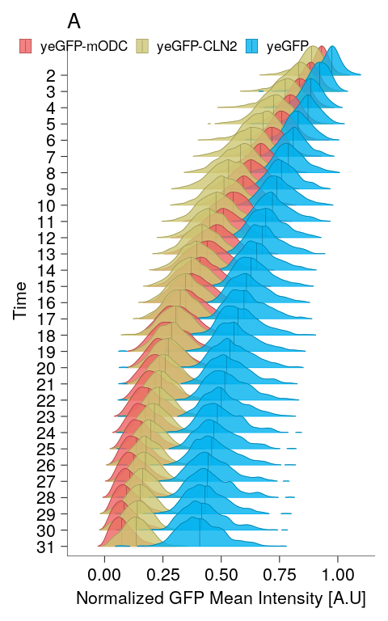

```r
gfpIntGGRid <- all.exp.list %>%
  filter(red == "pup1-rfp", treatment == "none", degron != "cln2.2") %>%
  left_join(.,pup1.cell.attr , by = c("cell.id","degron","red", "treatment","exp.field")) %>%
  filter(degron %in% c("mODC.2","cln2.3","stable.3")) %>%
  mutate(rfp.mean.bg.sub.puncta = ifelse(is.na(rfp.mean.bg.sub.puncta), 0, rfp.mean.bg.sub.puncta)) %>%
  filter(rfp.mean.bg.sub.puncta > 0, image.no < 32) %>%
  mutate(degron = case_when(degron %in% c("cln2.3","cln2.2","cln2", "cln2.4") ~ "yeGFP-CLN2",
                            degron %in% c("mODC.2", "mODC")  ~ "yeGFP-mODC",
                            degron %in% c("stable","stable.2","stable.3") ~ "yeGFP"),
         degron = factor(degron , levels = c("yeGFP-mODC","yeGFP-CLN2","yeGFP"))) %>%
  group_by(cell.id) %>%
  mutate(I0_It = gfpMeanBgAFsub/gfpMeanBgAFsub[1]) %>%
  filter(image.no > 1) %>%
  ggplot(.,aes(x = I0_It, y = factor(image.no, levels = c(31:2)) ,fill = degron, color = degron))+
  stat_density_ridges(geom = "density_ridges_gradient" ,
                      quantiles = 2,
                      quantile_lines = TRUE ,
                      aes(height = ..ndensity..),
                      rel_min_height = 0.01,
                      size = 0.1) +
  scale_fill_manual(values = alpha(c("indianred2","khaki3","deepskyblue2"), 0.8), name = NULL)+
  scale_color_manual(values = c("indianred4","khaki4","deepskyblue4"), name = NULL)+
  theme_ridges(line_size = 0.3)+
  theme_pubr()+
  theme(text = element_text(size = 8),
        legend.background = element_blank(),
        legend.direction = "horizontal",
        legend.position = c(0.3,factor(2, levels = 2)),
        legend.key.size = unit(2 ,"mm"),
        axis.line = element_line(size = 0.1),
        axis.ticks = element_line(size = 0.2))+
  # scale_x_log10(labels = scales::trans_format("log10", scales::math_format(10^.x)))+
  ylab("Time")+
  # xlab()+
  # xlim(0,1.1)+
  scale_x_continuous(breaks = seq(0,1,by = 0.25), name = "Normalized GFP Mean Intensity [A.U]", limits = c(-0.1,1.1))+
  labs(title = "A")

gfpIntGGRid
```

###Saving the plot

```r
# ggsave(plot = gfpIntGGRid, path = "~/plots/paper1/figures/fig_1/", filename = "gfpggrid.png", width = 2.5, height = 4)
```

#Panel B predicted values function

```r
dy.dm.f.fn <- function(dy, f, dm, delta.time){
  pred.gfp <- ((dy * (1 - f) * exp(-dy * delta.time)) / dm) +
              exp(-dy * delta.time) +
              (1 - exp(-dy * delta.time)) * f -
              ((dy * (1 - f) * exp(-(dy + dm) * delta.time)) / dm)
  return(pred.gfp)
}

dy.f.fn <- function(dy,f,delta.time){
  pred.gfp <-  exp(-dy * delta.time) +(1 - exp(-dy * delta.time)) * f
  return(pred.gfp)
}

exponential.fn <- function(dy, delta.time){
  pred.gfp <- exp(-dy * delta.time)
  return(pred.gfp)
}

dy.dm.fn <- function(dy, dm, delta.time){
  pred.gfp <- ((dy  * exp(-dy * delta.time)) / dm) + exp(-dy * delta.time)  -
              ((dy * 1 * exp(-(dy + dm) * delta.time)) / dm)

  return(pred.gfp)
}
```

```r
fig1c.df <- all.exp.list %>%
  mutate(colony = case_when(exp.field %in% c("20min_s3", "20min_s4") ~ "Replicate 1",
                            exp.field %in% c("20min_s5", "20min_s6") ~ "Replicate 2",
                            exp.field %in% c("20min_s7", "20min_s8" ) ~ "Replicate 3")) %>%
  filter(cell.id %in% c( "1000002011_20min_s3_cln2.3_pup1-rfp_none",
                         "1000001808_20min_s7_mODC.2_pup1-rfp_none",
                         "1000001968_20min_s5_stable.3_pup1-rfp_none"
                         )) %>%
  left_join(.,aic.df, by = c("cell.id","red","degron","treatment","colony"))
```

###predicted values for each model tested

```r
fig1c.pred <- fig1c.df %>%
  dplyr::select(cell.id, delta.time, gfpMeanBgAFsub, degron, f, dy, dm, aic, value,model,colony) %>%
  group_by(cell.id) %>%
  mutate(pred.value =  case_when(model == "dy.dm.f" ~ dy.dm.f.fn(dy = dy,
                                                                dm = dm,
                                                               f = f,
                                                               delta.time = delta.time/60) ,
                               model == "dy.f" ~ dy.f.fn(f = f,
                                                         dy = dy,
                                                         delta.time = delta.time/60) ,
                               model == "exponential" ~ exponential.fn(dy = dy,
                                                                       delta.time = delta.time/60) ,
                               model == "dy.dm" ~ dy.dm.fn(dy = dy,
                                                           dm = dm,
                                                           delta.time = delta.time/60)) ,
         pred.gfp = gfpMeanBgAFsub[1]*pred.value)

#changing the levels of the degrons so they appeare in a particular order in facet_grid
fig1c.pred <- fig1c.pred %>%
  mutate( degron = case_when(degron == "cln2.3" ~ "yeGFP-CLN2",
                            degron == "mODC.2" ~ "yeGFP-mODC",
                            degron == "stable.3" ~ "yeGFP"),
          degron = factor(degron, levels = c("yeGFP-mODC","yeGFP-CLN2","yeGFP")))
```

###testing out single cell plot

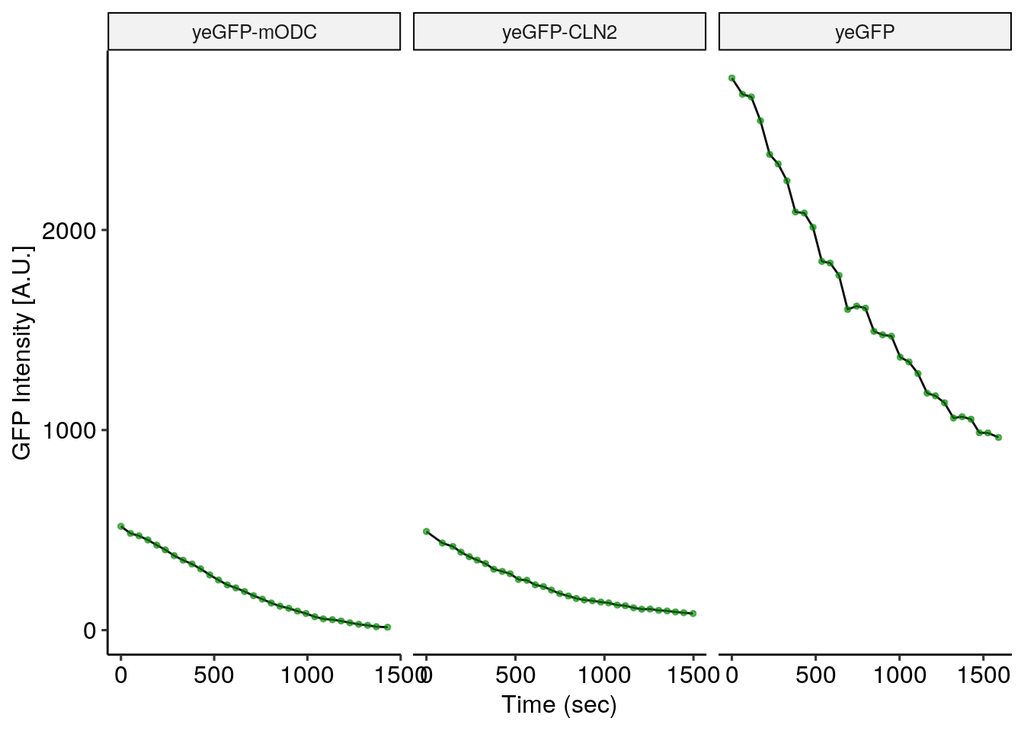

```r
fig1c.pred %>%
  ggplot(.,aes(x = delta.time, y = gfpMeanBgAFsub, group = cell.id))+
  geom_line(color = "gray4")+
  geom_point(size = 1, color = "green4", alpha = 0.2)+
  facet_grid(~degron, scales = "free")+
  theme_pubr()+
  xlab("Time (sec)")+
  ylab("GFP Intensity [A.U.]")
```

###Actual figure

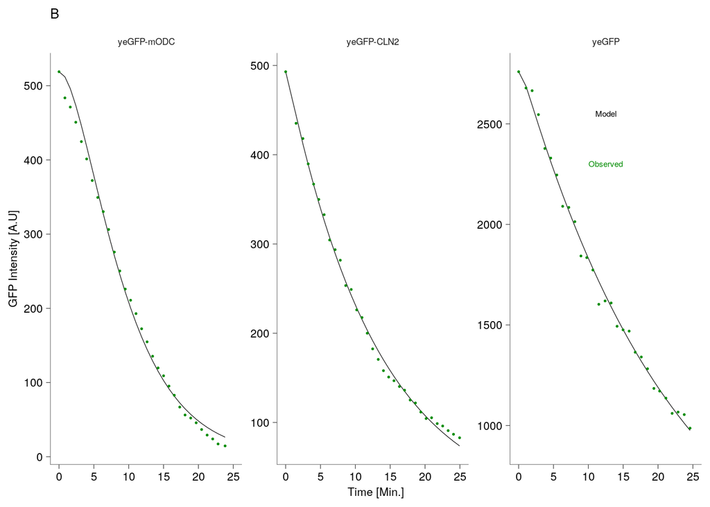

```r
GFPtrace.pup1Rep2022.grc <- fig1c.pred %>%
  group_by(cell.id) %>%
  mutate(dm = ifelse(is.na(dm), Inf, dm)) %>%
  filter( model == "dy.dm") %>%
  ggplot(.,aes(x = delta.time/60, y = pred.gfp))+
  geom_line(color = "black",
            size = 0.2)+
  geom_point(data = fig1c.pred %>%
              group_by(cell.id) %>%
              distinct(delta.time, .keep_all = TRUE) , aes(x = delta.time/60, y = gfpMeanBgAFsub),
            color = "green4",
            size = 0.25)+
  facet_wrap(~degron ,scales = "free")+
  theme_pubr()+
  theme(text = element_text(size = 8),
        axis.line = element_line(size = 0.1),
        axis.ticks = element_line(size = 0.2),
        strip.background = element_blank())+
        # axis.text.x = element_text(angle = 30))+
        # legend.position = c(0.9,0.95) ,
        # legend.background = element_blank(),
        # legend.spacing.y = unit(0.1, "cm") ,
        # legend.key.height = unit(1, "mm"))+
  # guides(fill = guide_legend(byrow = TRUE))+
  xlab("Time [Min.]")+
  ylab("GFP Intensity [A.U]")+
  labs(title = "B")+
  scale_x_continuous(breaks = c(0,5,10,15,20,25), limits = c(0,25))+
  scale_color_manual(values = c("green4" , "black") , name = NULL, labels = c("Observed", "Predicted"))+
  geom_text(data = fig1c.pred %>%
              group_by(cell.id) %>%
              distinct(delta.time, .keep_all = TRUE) %>%
              filter(delta.time == 0 ,
                     degron == "yeGFP") %>%
              slice(rep(1:n(), 2)) %>%
              mutate(delta.time = c(750,750),
                     pred.gfp =c(2550,2300)),
            label = c("Model" , "Observed"),
            color = c("black","green4"),
            size = 2)

GFPtrace.pup1Rep2022.grc
```

###saving the plot

```r
# ggsave(plot = GFPtrace.pup1Rep2022.grc, filename = "GFPTrace_singCell.png", path = "~/plots/paper1/figures/fig_1/GRC/", width = 4, height = 2)
```

#Panel C changing the colony values to include all the replicates

```r
aic.df.allreps <- aic.df %>%
  filter(red == "pup1-rfp", treatment == "none",
         degron %in% c("cln2.3","cln2.2","cln2","cln2.4",
                       "mODC","mODC.2",
                       "stable","stable.2","stable.3") ) %>%
  filter(ifelse(degron %in% c( "stable.2", "stable", "stable.3"), dy < 0.1, dy < 0.5)) %>%
  group_by(cell.id) %>%
  filter(model == "dy.dm", dm > 0.000015) %>%
  left_join(.,pup1.cell.attr , by = c("cell.id","degron","red", "treatment", "exp.field","colony")) %>%
  mutate(colony = case_when(degron == "cln2.2" & colony == "Replicate 1"~ "Replicate 4",
                            degron == "cln2.2" & colony == "Replicate 2"~ "Replicate 5",
                            degron == "cln2.2" & colony == "Replicate 3"~ "Replicate 6",
                            degron == "cln2" & colony == "Replicate 1"~ "Replicate 7",
                            degron == "cln2" & colony == "Replicate 2"~ "Replicate 8",
                            degron == "cln2" & colony == "Replicate 3"~ "Replicate 9",
                            degron == "cln2.4" & colony == "Replicate 1"~ "Replicate 10",
                            degron == "cln2.4" & colony == "Replicate 2"~ "Replicate 11",
                            degron == "cln2.4" & colony == "Replicate 3"~ "Replicate 12",
                            degron == "mODC" & colony == "Replicate 1"~ "Replicate 4",
                            degron == "mODC" & colony == "Replicate 2"~ "Replicate 5",
                            degron == "mODC" & colony == "Replicate 3"~ "Replicate 6",
                            degron == "stable" & colony == "Replicate 1"~ "Replicate 4",
                            degron == "stable" & colony == "Replicate 2"~ "Replicate 5",
                            degron == "stable" & colony == "Replicate 3"~ "Replicate 6",
                            degron == "stable.3" & colony == "Replicate 1"~ "Replicate 7",
                            degron == "stable.3" & colony == "Replicate 2"~ "Replicate 8",
                            degron == "stable.3" & colony == "Replicate 3"~ "Replicate 9",
                            TRUE ~ colony))

# aic.df.allreps %>%
#   mutate(t.half = log(2)/dy) %>%
#   filter(t.half > 50)
```

```r
aic.df.allreps %>% group_by(degron, colony) %>% tally()
```

```
## # A tibble: 27 × 3
## # Groups:   degron [9]
##    degron colony           n
##    <chr>  <chr>        <int>
##  1 cln2   Replicate 7     48
##  2 cln2   Replicate 8     24
##  3 cln2   Replicate 9     82
##  4 cln2.2 Replicate 4    464
##  5 cln2.2 Replicate 5    410
##  6 cln2.2 Replicate 6    448
##  7 cln2.3 Replicate 1    562
##  8 cln2.3 Replicate 2    384
##  9 cln2.3 Replicate 3    462
## 10 cln2.4 Replicate 10   116
## # … with 17 more rows
```

getting the median values of the half lives for each GFP (mODC, CLN2 and the stable) using all the reps

```r
# avg.half <- aic.df.allreps %>%
#   # left_join(.,pup1.cell.attr %>% select(-colony) , by = c("cell.id","degron","red", "treatment", "exp.field")) %>%
#   filter(degron %in% c("mODC.2","cln2.3","cln2.4","stable.3","stable.2")) %>%
#   mutate(degron = case_when(degron %in% c("cln2.3","cln2.2","cln2","cln2.4") ~ "GFP-CLN2",
#                             degron %in% c("mODC.2", "mODC")  ~ "GFP-mODC",
#                             degron %in% c("stable","stable.2","stable.3") ~ "GFP"),
#          degron = factor(degron , levels = c("GFP-mODC","GFP-CLN2","GFP")) ,
#          t.half = log(2)/dy,
#          rfp.mean.bg.sub.puncta = ifelse(is.na(rfp.mean.bg.sub.puncta), 0, rfp.mean.bg.sub.puncta)) %>%
#   filter(rfp.mean.bg.sub.puncta >0) %>%
#   group_by(degron) %>%
#   summarise(avg.t = median(t.half))
```

###with all the reps

```r
# pup1RFP.halfLives.allreps <- aic.df.allreps %>%
#   # left_join(.,pup1.cell.attr , by = c("cell.id","degron","red", "treatment")) %>%
#   mutate(degron = case_when(degron %in% c("cln2.3","cln2.2","cln2","cln2.4") ~ "GFP-CLN2",
#                             degron %in% c("mODC.2", "mODC")  ~ "GFP-mODC",
#                             degron %in% c("stable","stable.2","stable.3") ~ "GFP"),
#          degron = factor(degron , levels = c("GFP-mODC","GFP-CLN2","GFP")),
#          colony = as.numeric(str_remove(string = colony, pattern = "Replicate ")) ,
#          colony = factor(colony, levels = c(1:12))) %>%
#   filter(ifelse(degron == "GFP", gfp.mean.bg.af.sub.new > 1000 , gfp.mean.bg.af.sub.new > 0 )) %>%
#   ggplot(.,aes(y = log(2)/dy, x = degron, fill = colony))+
#   geom_hline(data = avg.half, aes(yintercept = avg.t, linetype = degron))+
#   geom_boxplot( outlier.size = 0.5)+
#   # geom_jitter(position = position_jitterdodge(jitter.height = 0, jitter.width = 0.1), size = 0.2, alpha = 0.2)+
#   theme_pubr()+
#   # scale_fill_brewer(name = "Replicate", palette = "Set2")+
#   ylab("Half-Life [Min.]")+
#   theme(axis.title.x = element_blank(),
#         text = element_text(size = 6),
#         legend.position = c(0.4, 0.8),
#         legend.direction = "horizontal",
#         legend.background = element_blank(),
#         legend.key.size = unit(3 ,"mm"),
#         legend.spacing.y = unit(-0.25, "cm"))
#
#
# pup1RFP.halfLives.allreps
```

###For GRC 2023 and for paper only one set of experiment for each GFP (each contains 3 biologiical replicates)

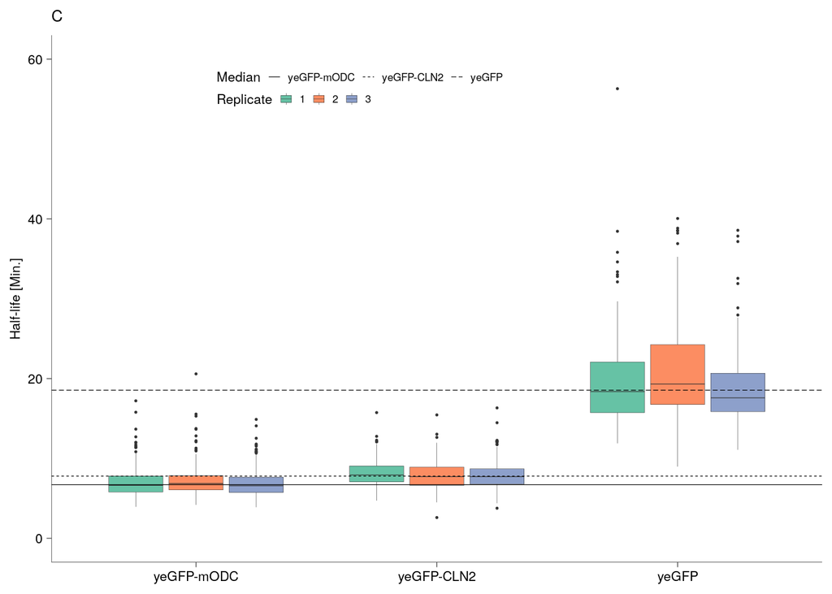

```r
#getting the median value of half lives for each GFP keeping only one set of experiments each containing three biological replicates
avg.half.grc <- aic.df.allreps %>%
  # left_join(.,pup1.cell.attr %>% select(-colony) , by = c("cell.id","degron","red", "treatment", "exp.field")) %>%
  filter(degron %in% c("mODC.2","cln2.3","stable.3")) %>%
  mutate(degron = case_when(degron %in% c("cln2.3","cln2.2","cln2","cln2.4") ~ "yeGFP-CLN2",
                            degron %in% c("mODC.2", "mODC")  ~ "yeGFP-mODC",
                            degron %in% c("stable","stable.2","stable.3") ~ "yeGFP"),
         degron = factor(degron , levels = c("yeGFP-mODC","yeGFP-CLN2","yeGFP")) ,
         t.half = log(2)/dy,
         rfp.mean.bg.sub.puncta = ifelse(is.na(rfp.mean.bg.sub.puncta), 0, rfp.mean.bg.sub.puncta)) %>%
  filter(rfp.mean.bg.sub.puncta >0) %>%
  group_by(degron) %>%
  summarise(avg.t = median(t.half))

#plot
pup1RFP.halfLives.oneReps.grc <-  aic.df.allreps %>%
  filter(degron %in% c("mODC.2","cln2.3","stable.3")) %>%
  mutate(rfp.mean.bg.sub.puncta = ifelse(is.na(rfp.mean.bg.sub.puncta), 0, rfp.mean.bg.sub.puncta)) %>%
  filter(rfp.mean.bg.sub.puncta > 0) %>%
  mutate(colony = case_when(degron == "stable.3" & colony == "Replicate 7"~ "Replicate 1",
                            degron == "stable.3" & colony == "Replicate 8"~ "Replicate 2",
                            degron == "stable.3" & colony == "Replicate 9"~ "Replicate 3",
                            degron == "cln2.4" & colony == "Replicate 10" ~ "Replicate 4",
                            degron == "cln2.4" & colony == "Replicate 11" ~ "Replicate 5",
                            degron == "cln2.4" & colony == "Replicate 12" ~ "Replicate 6",
                            TRUE ~ colony)) %>%
  mutate(degron = case_when(degron %in% c("cln2.3","cln2.2","cln2","cln2.4") ~ "yeGFP-CLN2",
                            degron %in% c("mODC.2", "mODC")  ~ "yeGFP-mODC",
                            degron %in% c("stable","stable.2","stable.3") ~ "yeGFP"),
         degron = factor(degron , levels = c("yeGFP-mODC","yeGFP-CLN2","yeGFP")),
         colony = as.numeric(str_remove(string = colony, pattern = "Replicate ")) ,
         colony = factor(colony, levels = c(1:12))) %>%
  ggplot(.,aes(y = log(2)/dy, x = degron, fill = colony))+
  geom_boxplot(outlier.size = 0.2, lwd = 0.1)+
  geom_hline(data = avg.half.grc %>% rename("Median"="degron"),
             aes(yintercept = avg.t, linetype = Median),
             size = 0.2)+
  theme_pubr()+
  scale_fill_brewer(name = "Replicate", palette = "Set2")+
  ylab("Half-life [Min.]")+
  labs(title = "C")+
  theme(axis.title.x = element_blank(),
        axis.line = element_line(size = 0.1),
        axis.ticks = element_line(size = 0.2),
        text = element_text(size = 8),
        legend.position = c(0.4,0.9),
        legend.direction = "horizontal",
        legend.background = element_blank(),
        legend.key.size = unit(3 ,"mm"),
        legend.spacing.y = unit(-0.25, "cm"))+
  ylim(0,60)
  # scale_y_log10()

pup1RFP.halfLives.oneReps.grc
```

###save the plot as png

```r
# ggsave(plot = pup1RFP.halfLives.oneReps.grc, filename = "pup1RFP_halfLife.png", path = "~/plots/paper1/figures/fig_1/GRC/", width = 7, height = 4)
```

#Panel D ###cv of t.half ###using all the replicates calculating the cv and median cv of t.half

```r
cv.half <-  aic.df.allreps %>%
  filter(degron %in% c("mODC.2","cln2.3","cln2.4","stable.2","stable.3")) %>%
  mutate(rfp.mean.bg.sub.puncta = ifelse(is.na(rfp.mean.bg.sub.puncta), 0, rfp.mean.bg.sub.puncta)) %>%
  filter(rfp.mean.bg.sub.puncta > 0) %>%
  mutate(colony = case_when(degron == "stable.3" & colony == "Replicate 7"~ "Replicate 4",
                            degron == "stable.3" & colony == "Replicate 8"~ "Replicate 5",
                            degron == "stable.3" & colony == "Replicate 9"~ "Replicate 6",
                            degron == "cln2.4" & colony == "Replicate 10" ~ "Replicate 4",
                            degron == "cln2.4" & colony == "Replicate 11" ~ "Replicate 5",
                            degron == "cln2.4" & colony == "Replicate 12" ~ "Replicate 6",
                            TRUE ~ colony)) %>%
  mutate(degron = case_when(degron %in% c("cln2.3","cln2.2","cln2","cln2.4") ~ "GFP-CLN2",
                            degron %in% c("mODC.2", "mODC")  ~ "GFP-mODC",
                            degron %in% c("stable","stable.2","stable.3") ~ "GFP"),
         degron = factor(degron , levels = c("GFP-mODC","GFP-CLN2","GFP")),
         colony = as.numeric(str_remove(string = colony, pattern = "Replicate ")),
         t.half = log(2)/dy) %>%
  group_by(degron,colony) %>%
  summarise(dy.avg = mean(dy),
            dy.std = sd(dy),
            t.half.avg = median(t.half),
            t.half.std = sd(t.half) ,
            t.half.max = max(t.half),
            t.half.min = min(t.half),
            cv.half = sd(t.half)/mean(t.half),
            cv2.half = var(t.half)/mean(t.half),
            no.cells = NROW(dy),
            range.half = t.half.max/t.half.min) %>%
   mutate_if(is.numeric, ~round(.,digits = 2))
```

```
## `mutate_if()` ignored the following grouping variables:
```

```r
#median between all the replicates
cv.half.median <- cv.half %>%
  ungroup() %>%
  group_by(degron) %>%
  summarise(cv.half = median(cv.half))
```

###For GRC 2023 and paper only kept three replicates

```r
cv.half.grc <-  aic.df.allreps %>%
  filter(degron %in% c("mODC.2","cln2.3","stable.3")) %>%
  mutate(rfp.mean.bg.sub.puncta = ifelse(is.na(rfp.mean.bg.sub.puncta), 0, rfp.mean.bg.sub.puncta)) %>%
  filter(rfp.mean.bg.sub.puncta > 0) %>%
  mutate(colony = case_when(degron == "stable.3" & colony == "Replicate 7"~ "Replicate 1",
                            degron == "stable.3" & colony == "Replicate 8"~ "Replicate 2",
                            degron == "stable.3" & colony == "Replicate 9"~ "Replicate 3",
                            degron == "cln2.4" & colony == "Replicate 10" ~ "Replicate 4",
                            degron == "cln2.4" & colony == "Replicate 11" ~ "Replicate 5",
                            degron == "cln2.4" & colony == "Replicate 12" ~ "Replicate 6",
                            TRUE ~ colony)) %>%
  mutate(degron = case_when(degron %in% c("cln2.3","cln2.2","cln2","cln2.4") ~ "yeGFP-CLN2",
                            degron %in% c("mODC.2", "mODC")  ~ "yeGFP-mODC",
                            degron %in% c("stable","stable.2","stable.3") ~ "yeGFP"),
         degron = factor(degron , levels = c("yeGFP-mODC","yeGFP-CLN2","yeGFP")),
         colony = as.numeric(str_remove(string = colony, pattern = "Replicate ")),
         t.half = log(2)/dy) %>%
  group_by(degron,colony) %>%
  summarise(dy.avg = mean(dy),
            dy.std = sd(dy),
            t.half.avg = median(t.half),
            t.half.std = sd(t.half) ,
            t.half.max = max(t.half),
            t.half.min = min(t.half),
            cv.half = sd(t.half)/mean(t.half),
            cv2.half = var(t.half)/mean(t.half),
            no.cells = NROW(dy),
            range.half = t.half.max/t.half.min) %>%
   mutate_if(is.numeric, ~round(.,digits = 2))
```

```
## `mutate_if()` ignored the following grouping variables:
```

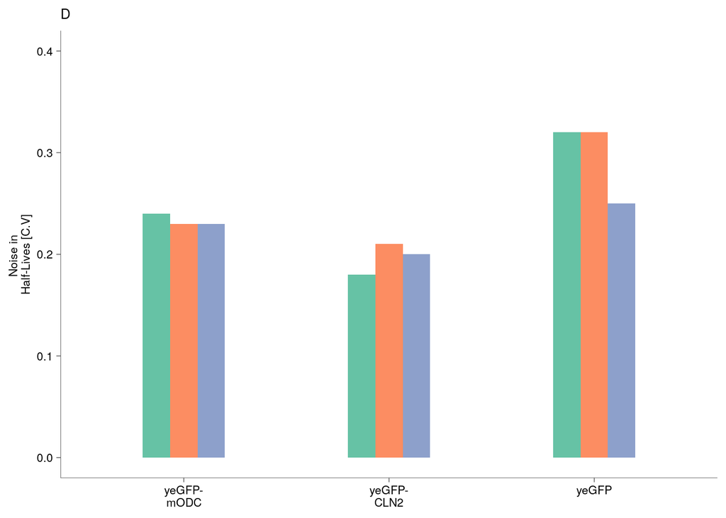

```r
#median between all the replicates
cv.half.median.grc <- cv.half.grc %>%
  ungroup() %>%
  group_by(degron) %>%
  summarise(cv.half = median(cv.half))

cvtHalf.plt.grc <- cv.half.grc %>%
  ggplot(.,aes(y = cv.half, x = degron, fill = factor(colony, levels = c(1:12))))+
  geom_col(width = 0.4, position = "dodge")+
  # geom_point(position = position_jitter(seed = 1, width = 0.1), size = 0.5)+
  # geom_jitter(width = 0.1, size = 0.5, seed = 1)+
  # geom_crossbar(data=cv.half.median, aes(ymin = cv.half, ymax = cv.half),
                  # size=0.1, col="black", width = .25)+
  theme_pubr()+
  scale_fill_brewer(name = "Replicate", palette = "Set2", guide = "none")+
  ylab("Noise in \nHalf-Lives [C.V]")+
  labs(title = "D")+
  scale_x_discrete(labels = function(x) str_wrap(x, width = 5))+
  theme(axis.title.x = element_blank(),
        axis.line = element_line(size = 0.1),
        axis.ticks = element_line(size = 0.2),
        text = element_text(size = 8),
        legend.position = c(0.4,0.9),
        legend.direction = "horizontal",
        legend.background = element_blank(),
        legend.key.size = unit(3 ,"mm"),
        legend.spacing.y = unit(-0.25, "cm"))+
  ylim(0,0.4)

cvtHalf.plt.grc
```

###save the plot

```r
ggsave(plot = cvtHalf.plt.grc, filename = "cv_halfLife.png", path = "~/plots/paper1/figures/fig_1/GRC/", width = 5, height = 3)
```

#Panel E gfp int cv ###only three replicates for each GFP

```r
cv.gfp.grc <-  aic.df.allreps %>%
  filter(degron %in% c("mODC.2","cln2.3","stable.3")) %>%
  mutate(rfp.mean.bg.sub.puncta = ifelse(is.na(rfp.mean.bg.sub.puncta), 0, rfp.mean.bg.sub.puncta)) %>%
  filter(rfp.mean.bg.sub.puncta > 0) %>%
  mutate(colony = case_when(degron == "stable.3" & colony == "Replicate 7"~ "Replicate 1",
                            degron == "stable.3" & colony == "Replicate 8"~ "Replicate 2",
                            degron == "stable.3" & colony == "Replicate 9"~ "Replicate 3",
                            degron == "cln2.4" & colony == "Replicate 10" ~ "Replicate 4",
                            degron == "cln2.4" & colony == "Replicate 11" ~ "Replicate 5",
                            degron == "cln2.4" & colony == "Replicate 12" ~ "Replicate 6",
                            TRUE ~ colony)) %>%
  mutate(degron = case_when(degron %in% c("cln2.3","cln2.2","cln2","cln2.4") ~ "yeGFP-CLN2",
                            degron %in% c("mODC.2", "mODC")  ~ "yeGFP-mODC",
                            degron %in% c("stable","stable.2","stable.3") ~ "yeGFP"),
         degron = factor(degron , levels = c("yeGFP-mODC","yeGFP-CLN2","yeGFP")),
         colony = as.numeric(str_remove(string = colony, pattern = "Replicate ")),
         t.half = log(2)/dy) %>%
  group_by(degron,colony) %>%
  summarise(gfp.avg = mean(gfp.mean.bg.af.sub.new),
            gfp.std = sd(gfp.mean.bg.af.sub.new),
            gfp.max = max(gfp.mean.bg.af.sub.new),
            gfp.min = min(gfp.mean.bg.af.sub.new),
            cv.gfp = sd(gfp.mean.bg.af.sub.new)/mean(gfp.mean.bg.af.sub.new),
            cv2.gfp = var(gfp.mean.bg.af.sub.new)/mean(gfp.mean.bg.af.sub.new),
            no.cells = NROW(dy)) %>%
   mutate_if(is.numeric, ~round(.,digits = 2))
```

```
## `mutate_if()` ignored the following grouping variables:
```

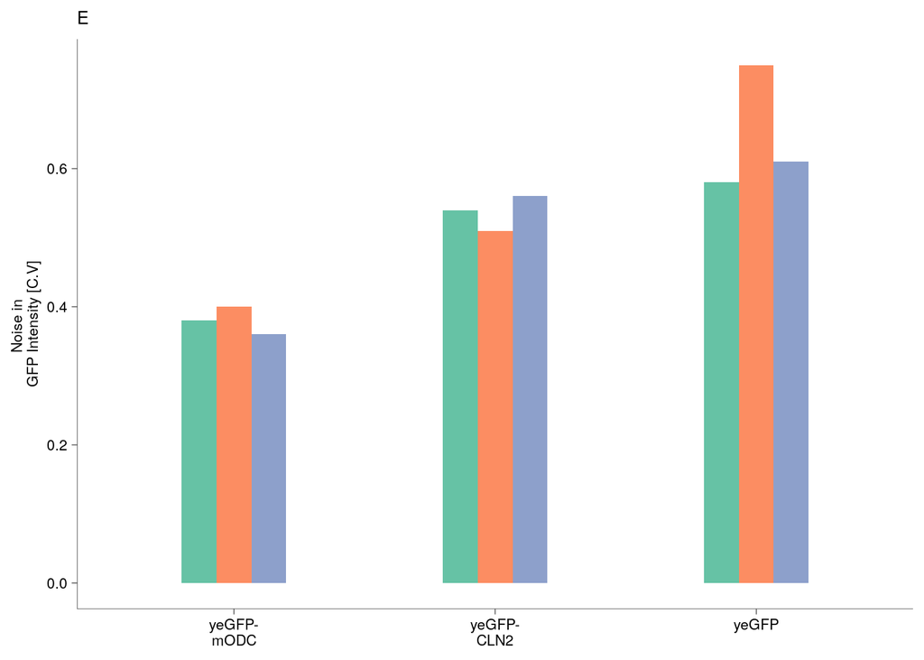

```r
cvGFP.plt.grc <- cv.gfp.grc %>%
  ggplot(.,aes(y = cv.gfp, x = degron, fill = factor(colony, levels = c(1:12))))+
  geom_col(width = 0.4, position = "dodge")+
  # geom_point(position = position_jitter(seed = 1, width = 0.1), size = 0.5)+
  # geom_jitter(width = 0.1, size = 0.5, seed = 1)+
  # geom_crossbar(data=cv.half.median, aes(ymin = cv.half, ymax = cv.half),
                  # size=0.1, col="black", width = .25)+
  theme_pubr()+
  scale_fill_brewer(name = "Replicate", palette = "Set2", guide = "none")+
  ylab("Noise in \nGFP Intensity [C.V]")+
  labs(title = "E")+
  scale_x_discrete(labels = function(x) str_wrap(x, width = 5))+
  theme(axis.title.x = element_blank(),
        axis.line = element_line(size = 0.1),
        axis.ticks = element_line(size = 0.2),
        text = element_text(size = 8), #changed from 12 to 8 for paper
        legend.position = c(0.4,0.9),
        legend.direction = "horizontal",
        legend.background = element_blank(),
        legend.key.size = unit(3 ,"mm"),
        legend.spacing.y = unit(-0.25, "cm"))

cvGFP.plt.grc
```

```r
ggsave(plot = cvGFP.plt.grc, filename = "cv_GFP.png", path = "~/plots/paper1/figures/fig_1/GRC/", width = 5, height = 3)
```

#Putting the entire figure together ###fig 2: with only three replicates for each

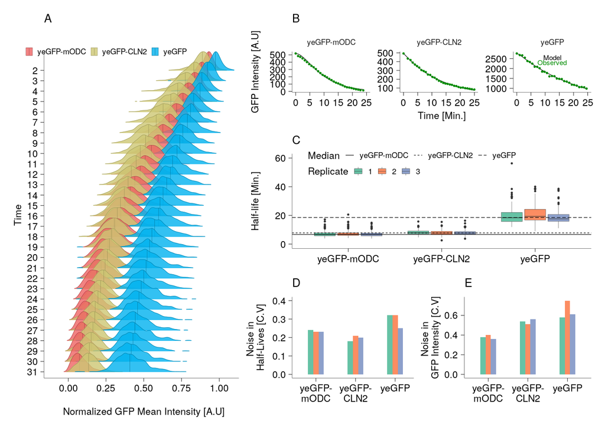

```r
right.bot.sec <- ((cvtHalf.plt.grc+plot_spacer()+cvGFP.plt.grc))+
                plot_layout(widths = c(0.5,-0.1,0.5))

right.sec <- (GFPtrace.pup1Rep2022.grc/
                pup1RFP.halfLives.oneReps.grc/right.bot.sec)+
  plot_layout(heights = c(0.3,0.7,0.6))

# left.sec <- (top.sec.1/mid.sec)+
#   plot_layout(heights = c(0.6,0.4))

left.sec <- gfpIntGGRid


figGFP.timelapse <-  (left.sec+plot_spacer()+right.sec)+
  plot_layout(widths = c(0.4,-0.05,0.6))

figGFP.timelapse
```

#saving the final figure in pdf and png formate

```r
ggsave(plot = figGFP.timelapse, path = "~/plots/paper1/figures/fig_1/", filename = "figGFP_Timelapse.pdf", width = 7, height = 5 )
ggsave(plot = figGFP.timelapse, path = "~/plots/paper1/figures/fig_1/", filename = "figGFP_Timelapse.png", width = 7, height = 5)
```